# Exercise #1

Fortgeschrittene Statistische Software für NF

Akram Helal, Seyed Ramtin Hosseini  
2025-05-06

## General Remarks

- You can submit your solutions in teams of up to 3 students.
- Include all your team-member’s names and student numbers (Martrikelnummern) in the `authors` field.
- Please use the exercise template document to work on and submit your results.
- Use a level 2 heading for each new exercise and answer each subtask next to it’s bullet point or use a new level 3 heading if you want.
- Always render the R code for your solutions and make sure to include the resulting data in your rendered document.
  - Make sure to not print more than 10 rows of data (unless specifically instructed to).
- Always submit both the rendered document(s) as well as your source Rmarkdown or Quarto document. Submit the files separately on moodle, **not** as a zip archive.
- Submission format for the rendered document(s) is HTML. Other formats will lead to a deduction of points.

## Special Note for Exercise Sheet 1 (1 Point)

As we are focusing on Rmarkdown itself for this first exercise sheet, we kindly ask you to submit solutions as both HTML and PDF document.

- For the HTML document, please use the `distill` package as a template.
- For the PDF document you can use the standard PDF renderer in Rmarkdown. You can use the dropdown menu on the `Knit` button to manually render to PDF.

Note: If you have some issues with rendering to PDF this is really not a big problem, it will not cost you many points.

## Exercise 1: Penguins (5 Points)

Install the `palmerpenguins` package and load the `penguins` dataset into your environment.

### Installing palmerpenguins for the penguins dataset

```r
# Only once
#install.packages("palmerpenguins")
#install.packages("kableExtra")
#install.packages("knitr")

library(tidyverse)
library(palmerpenguins)
library(knitr)
library(kableExtra)
data("penguins")
```

1. Compute how many female and male species are available for each species on each island. What do you notice in the data?

```r
female_male_penguins_count <- penguins %>%
  # Group by penguins species, island and sex
  group_by(species, island, sex) %>%
  # Count penguins in each group
  summarise(count = n())

# Show first 10 Rows
knitr::kable(head(female_male_penguins_count, 10),
             col.names = c("Species", "Island", "Sex", "Count"),
             format = "markdown",
             caption = "Female and male species on different ilands")
```

Table 1: Female and male species on different ilands

| Species | Island | Sex | Count |
| --- | --- | --- | --- |
| Adelie | Biscoe | female | 22 |
| Adelie | Biscoe | male | 22 |
| Adelie | Dream | female | 27 |
| Adelie | Dream | male | 28 |
| Adelie | Dream | NA | 1 |
| Adelie | Torgersen | female | 24 |
| Adelie | Torgersen | male | 23 |
| Adelie | Torgersen | NA | 5 |
| Chinstrap | Dream | female | 34 |
| Chinstrap | Dream | male | 34 |

We can notice that there are 3 groups that do not have any values (NA) for the sex. Since the task above states, that only 10 rows are allowed to be showed (max), we can only see 2 groups with no values.

2. Change the previous code to resolve the issue and save the dataframe.

```r
female_male_penguins_count <- penguins %>%
  # Remove all rows where there are NA values in the sex column
  filter(!is.na(sex)) %>%
  # Group by penguins species, island and sex
  group_by(species, island, sex) %>%
  # Count penguins in each group
  summarise(count = n())

# Show all 10 observation
knitr::kable(female_male_penguins_count,
             col.names = c("Species", "Island", "Sex", "Count"),
             format = "markdown",
             caption = "Female and male species on different ilands (with removed NA-values)")
```

Table 2: Female and male species on different ilands (with removed NA-values)

| Species | Island | Sex | Count |
| --- | --- | --- | --- |
| Adelie | Biscoe | female | 22 |
| Adelie | Biscoe | male | 22 |
| Adelie | Dream | female | 27 |
| Adelie | Dream | male | 28 |
| Adelie | Torgersen | female | 24 |
| Adelie | Torgersen | male | 23 |
| Chinstrap | Dream | female | 34 |
| Chinstrap | Dream | male | 34 |
| Gentoo | Biscoe | female | 58 |
| Gentoo | Biscoe | male | 61 |

To remove those coloums with NA we just filter them out.

3. Create an appropriate visualization to display sex, species and island. Note: You need to transform the data first. Label the axes, give the graphic a title and make sure that basic visualization standards are maintained. Interpret what you see in one sentence

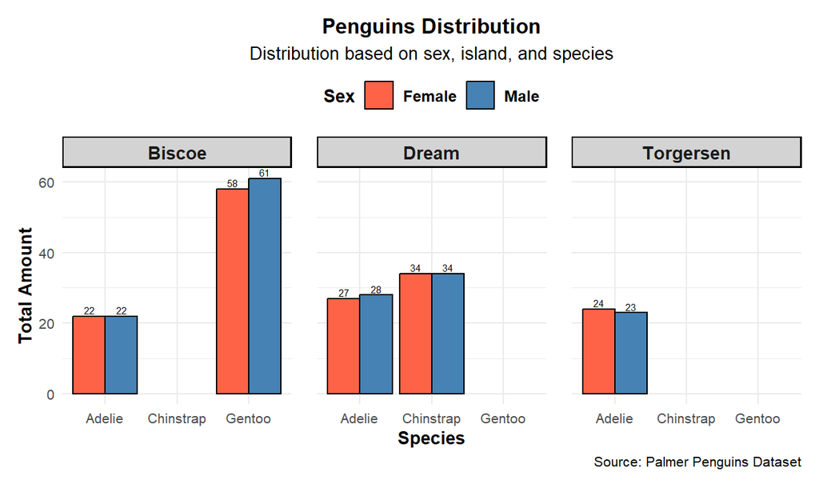

```r
ggplot(female_male_penguins_count, aes(x = species, y = count, fill = sex)) +
  geom_bar(
    stat = "summary",
    fun = sum,
    position = position_dodge(width = 0.9),
    color = "black" # optional: black outline around bars
    ) +
  geom_text(
    stat = "summary",
    fun = sum,
    aes(label = after_stat(y)),
    position = position_dodge(width = 0.9),
    vjust = -0.3,
    size = 2
    ) +
  scale_fill_manual(
    values = c("male" = "steelblue", "female" = "tomato"),
    name = "Sex",
    labels = c(
      male = expression(bold("Male")),
      female = expression(bold("Female"))
      )
    ) +
  labs(
    title = "Penguins Distribution",
    subtitle = "Distribution based on sex, island, and species",
    x = "Species",
    y = "Total Amount",
    caption = "Source: Palmer Penguins Dataset"
    ) +
  facet_wrap(~ island, nrow = 1) +
  theme_minimal(base_size = 10) +
  theme(
    plot.title = element_text(face = "bold", size = 12, hjust = 0.5),
    plot.subtitle = element_text(size = 10, hjust = 0.5),
    axis.title.x = element_text(face = "bold", size = 10),
    axis.title.y = element_text(face = "bold", size = 10),
    legend.title = element_text(face = "bold", size = 10),
    legend.text = element_text(size = 9),
    strip.background = element_rect(fill = "lightgray", color = "black", linewidth = 0.8),
    strip.text = element_text(face = "bold", size = 10),
    panel.spacing = unit(1, "lines"),
    plot.margin = margin(t = 10, r = 10, b = 20, l = 10),
    legend.position = "top"
    )
```

### Interpretation:

The bar chart illustrates the distribution of male and female penguins across the three islands Biscoe, Dream and Torgersen. There are three species: Adelie, Chinstrap and Gentoo. The Adelie penguin appears on all three islands, indicating that it is a more ecologically flexible species, capable of inhabiting diverse environments. In contrast, Chinstrap penguins are only found on Dream Island and Gentoo penguins are only found on Biscoe Island , suggesting a more restricted habitat preference. Gentoo and Chinstrap penguins are completely absent from Torgersen Island, implying that this location may not provide suitable conditions for that species

4. What is the average body mass of penguins of each species?

```r
average_body_mass <- penguins %>%
  group_by(species) %>%
  # na.rm = True, removes NA Values
  summarise(average_mass = round(mean(body_mass_g, na.rm = TRUE), 2))

knitr::kable(average_body_mass,
             col.names = c("Species", "Average mass in gramms"),
             format = "markdown",
             caption = "Average Body Mass of penguins of each species")
```

Table 3: Average Body Mass of penguins of each species

| Species | Average mass in gramms |
| --- | --- |
| Adelie | 3700.66 |
| Chinstrap | 3733.09 |
| Gentoo | 5076.02 |

## Exercise 2: Spotify top chart songs 2022 (4 Points)

Download the chart songs dataset from moodle and load it into R. The data is provided by the data science competition platform [Kaggle](https://www.kaggle.com/). You can find a detailed description of all variables in the data on the Kaggle website at https://www.kaggle.com/datasets/sveta151/spotify-top-chart-songs-2022 and a short description below.

1. Create a table displaying the top 15 songs in the dataset, including the song title, the artists’ names, their peak rank and the number of weeks in the charts. `knitr::kable()`.

```r
# load dataset, from Moodle [26.04.2025]
spotify_data <- read_delim("spotify_top_charts_22.csv", delim = ",")

spotify_top_songs <- spotify_data %>%
  # Arrange Dataset by descending order on weeks_on_chart
  arrange(peak_rank, desc(weeks_on_chart)) %>%
  # We want only the first 15 rows
  slice_head(n = 15) %>%
  select(track_name, artist_names, peak_rank, weeks_on_chart)

knitr::kable(spotify_top_songs,
             # rename coloumns
             col.names = c("Song Title", "Artist Names", "Peak Rank", "Weeks on Chart"),
             caption = "Top 15 Songs (Sorted by Peak Rank)",
             format = "markdown")
```

Table 4: Top 15 Songs (Sorted by Peak Rank)

| Song Title | Artist Names | Peak Rank | Weeks on Chart |
| --- | --- | --- | --- |
| Shape of You | Ed Sheeran | 1 | 269 |
| Sunflower - Spider-Man: Into the Spider-Verse | Post Malone, Swae Lee | 1 | 179 |
| Dance Monkey | Tones And I | 1 | 140 |
| Señorita | Shawn Mendes, Camila Cabello | 1 | 138 |
| Circles | Post Malone | 1 | 134 |
| Blinding Lights | The Weeknd | 1 | 121 |
| Starboy | The Weeknd, Daft Punk | 1 | 97 |
| HUMBLE. | Kendrick Lamar | 1 | 96 |
| Mood (feat. iann dior) | 24kGoldn, iann dior | 1 | 85 |
| positions | Ariana Grande | 1 | 74 |
| DÁKITI | Bad Bunny, Jhay Cortez | 1 | 73 |
| Heat Waves | Glass Animals | 1 | 65 |
| drivers license | Olivia Rodrigo | 1 | 63 |
| Peaches (feat. Daniel Caesar & Giveon) | Justin Bieber, Daniel Caesar, Giveon | 1 | 53 |
| MONTERO (Call Me By Your Name) | Lil Nas X | 1 | 52 |

2. Add a caption to your table. Who wrote the second most popular song?

Caption has been added for a), above.

```r
spotify_best_second_song <- spotify_data %>%
  arrange(peak_rank, desc(weeks_on_chart)) %>%
  slice(2) %>%
  select(track_name, artist_names)

knitr::kable(spotify_best_second_song,
             col.names = c("Track Name", "Artist Name"),
             format = "markdown",
             caption = "Second most popular song")
```

Table 5: Second most popular song

| Track Name | Artist Name |
| --- | --- |
| Sunflower - Spider-Man: Into the Spider-Verse | Post Malone, Swae Lee |

3. Calculate the percentage of songs written in major modality. Hint: Check out the Kaggle website for details about the variables of the dataset.

```r
# major modality -> coloumn mode = 1

major_modality <- round(mean(spotify_data$mode == 1, na.rm = TRUE), 4)

cat("Percentage of songs written in major modality: ", major_modality * 100, "%\n")
```

```
Percentage of songs written in major modality:  57.74 %
```

4. Create a scatterplot, showing the danceability score of a song on the X-axis and the energy score on the Y-axis.

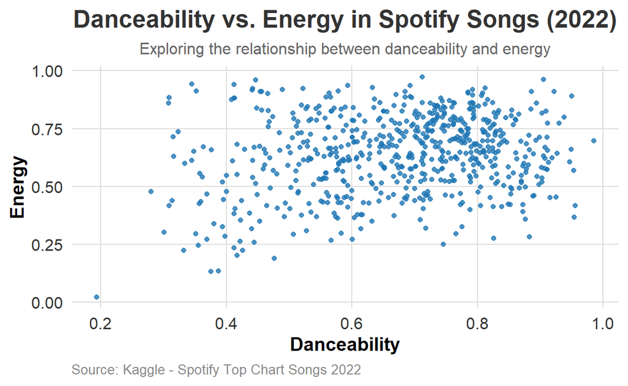

Figure 1: Scatterplot for Danceability and Energy for Spotifiy Songs.

```r
ggplot(spotify_data) +
  aes(x = danceability, y = energy) +
  geom_point(color = "#1F77B4", size = 1.5, alpha = 0.8) + # Clean color and transparency
  labs(
    title = "Danceability vs. Energy in Spotify Songs (2022)",
    subtitle = "Exploring the relationship between danceability and energy",
    x = "Danceability",
    y = "Energy",
    caption = "Source: Kaggle - Spotify Top Chart Songs 2022"
    ) +
  theme_minimal(base_size = 14) + # Minimal theme
  theme(
    plot.title = element_text(face = "bold", size = 18, hjust = 0.5, color = "#333333"),
    plot.subtitle = element_text(size = 12, hjust = 0.5, color = "#666666"),
    axis.title = element_text(face = "bold", size = 14),
    axis.text = element_text(size = 12, color = "#333333"),
    plot.caption = element_text(size = 10, hjust = 0, color = "#888888"),
    panel.grid.major = element_line(color = "#DDDDDD", linewidth = 0.5),
    panel.grid.minor = element_blank(),
    legend.position = "none" # No legend for simplicity
)
```

5. Add an appropriate caption to your figure (as part of the Rmarkdown, not within ggplot).

Caption has been added for d) above.

6. Write a short sentence describing and interpreting the figure. Properly [reference](https://bookdown.org/yihui/rmarkdown-cookbook/cross-ref.html) the figure in your sentence.

On the x-axis is the danceability with a score from zero to one and on the y-axis is the energy with a score from zero to one. As seen on the Figure 1, there is no clear pattern or relationship between danceability and energy.

7. Write another sentence describing that the figure was generated using `ggplot2` and add a [citation](https://bookdown.org/yihui/rmarkdown-cookbook/bibliography.html) for `ggplot2`.

The figure was generated using ggplot2 Wickham (2016).

8. Calculate the correlation between the danceability and the energy perception. Write a sentence in Markdown and automatically insert the correct number.

```r
cor_danceability_energy <- cor(spotify_data$danceability, spotify_data$energy, use = "complete.obs")
```

The correlation between energy and danceability is 0.1986587

## Exercise 3: Spotify top chart songs 2 (5 Points)

1. The number of weeks in charts and peak rank alone cannot fully reflect a song’s popularity: compare a song which was a one hit (aka one week) wonder with possibly peak rank 1 and a song ranking 10th place but for multiple weeks. Create a new combined `popularity_score` metric for songs which is calculated by dividing the number of weeks the song has been in the charts by its peak rank.

```r
spotify_data$popularity_score <- spotify_data$weeks_on_chart / spotify_data$peak_rank
```

2. Output a formatted table with the **top 15** songs ordered by this popularity score. Include the song title, the artists’ names, the weeks on chart, the peak rank and the popularity score.
- Add a caption to the table.
- Display the popularity score rounded to 3 digits, without rounding by hand.

> Tip: Check out the options in `knitr::kable()`

```r
spotify_popularity_score_top_songs <- spotify_data %>%
  arrange(desc(popularity_score)) %>%
  slice_head(n = 15)  %>%
  select(track_name, artist_names, weeks_on_chart, peak_rank, popularity_score)

# Round to 3 digits
spotify_popularity_score_top_songs$popularity_score <- round(spotify_popularity_score_top_songs$popularity_score, 3)

#?knitr::kable()
knitr::kable(spotify_popularity_score_top_songs,
             col.names = c("Song Title", "Artist Names", "Weeks on Chart", "Peak Rank", "Popularity Score"),
             format = "latex",
             caption = "Top 15 Songs ordered by Popularity Score",
             label = "top_songs",
             booktabs = TRUE) %>%
  kable_styling(latex_options = "HOLD_position", font_size = 8)
```

[output not shown]

3. Write one or two sentences describing the table, focusing on a comparison of its last two entries in particular. Include a link to the two songs and properly [reference](https://bookdown.org/yihui/rmarkdown-cookbook/cross-ref.html) the table.

> Note: Proper referencing of the table will only work when rendering to a PDF. Don’t get hung up on this if it provides some problems, as dealing with LaTeX can be a bit tricky.

4. Add a level-1 heading called `Supplementary Materials` and put the following figure under it.

# References

The figure was generated using ggplot2 (Wickham 2016).  
Details on cross-referencing can be found in (Xie 2020b).  
Details on bibliographies and citations can be found in (Xie 2020a).  
Materials and spotify data set can be found in (Lisa Bondo Andersen 2025).

# Supplementary Materials

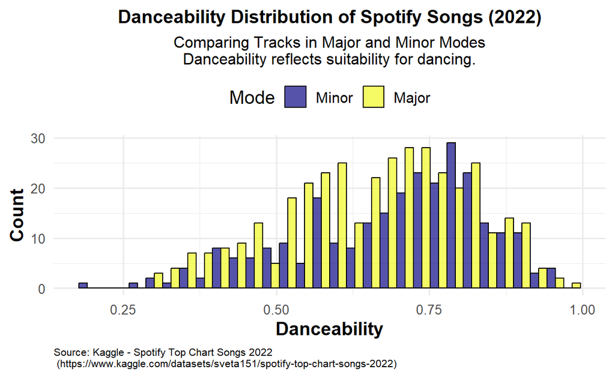

```r
spotify_data <- spotify_data %>% mutate(mode = as.factor(mode))

spotify_data$mode <- factor(spotify_data$mode, levels = c(0, 1), labels = c("Minor", "Major"))

ggplot(spotify_data) +
  aes(x = danceability, fill = mode) +
  geom_histogram(position = "dodge", bins = 30, color = "black", alpha = 0.7) + # Add border and transparency
  scale_fill_viridis_d(option = "plasma", direction = 1) +  # Color scale with plasma palette
  labs(
    title = "Danceability Distribution of Spotify Songs (2022)",
    subtitle = "Comparing Tracks in Major and Minor Modes\nDanceability reflects suitability for dancing.",
    x = "Danceability",
    y = "Count",
    caption = "Source: Kaggle - Spotify Top Chart Songs 2022\n (https://www.kaggle.com/datasets/sveta151/spotify-top-chart-songs-2022)",
    fill = "Mode"
  ) +
  theme_minimal(base_size = 14) +  # Clean, minimal theme with base font size 14
  theme(
    plot.title = element_text(face = "bold", size = 14, hjust = 0.5),
    plot.subtitle = element_text(size = 12, hjust = 0.5),
    axis.title = element_text(face = "bold", size = 14),
    axis.text = element_text(size = 10),
    plot.caption = element_text(size = 8, hjust = 0),
    legend.position = "top"  # Place the legend at the top for a cleaner look
  )
```

5. Create a histogram illustrating the danceability of the songs, coloured by modality.

The figure has been added above for d).

6. What do you notice in the histogram? Are there general trends across modalities or clear differences?

7. Include a the full [list of citations](https://bookdown.org/yihui/rmarkdown-cookbook/bibliography.html#include-appendix-after-bibliography) under a level-1 heading “References” including the details of your citation. Insert this list of references before the heading `Supplementary Materials`.

Lisa Bondo Andersen, Anna Steinberg. 2025. “Advanced Statistical Programming Using r.” https://moodle.lmu.de/course/view.php?id=39298.

Wickham, Hadley. 2016. *Ggplot2: Package of Tydiverse*.

Xie, Yihui. 2020a. “Bibliographies and Citations.” https://bookdown.org/yihui/rmarkdown-cookbook/bibliography.html.

———. 2020b. “Cross-Referencing Figures and Tables.” https://bookdown.org/yihui/rmarkdown-cookbook/cross-ref.html.